# Lab 10

Blue Team: Matt Lawson, Nick Zimmerman, Brandon Bowen, Bing Mitchel

March 22, 2019

```r
questions <- read_csv("data/Questions_trunc.csv")
answers <- read_csv("data/Answers_trunc.csv")

questions <- questions %>% select(Id:Body) %>% na.omit()
answers <- answers %>% select(Id:Body) %>% na.omit()
```

## Team What effects the score of a question the most?

We looked at if the question contained code, started with How, the amount of time it took to answer the question and API. From our data and graphs it can be seen that code, How questions and time all have positive effects on the team scores. Although API actualy had a negative affect which can be due to the difficulty of the questions. A good question to ask to expect fast respond time is To start the question with How which will be searched alot by other users and to include code for the question since we dealing with a type of forumn about python.

### Matt

**Does the `<code>` tag affect the score of a question or answer?**

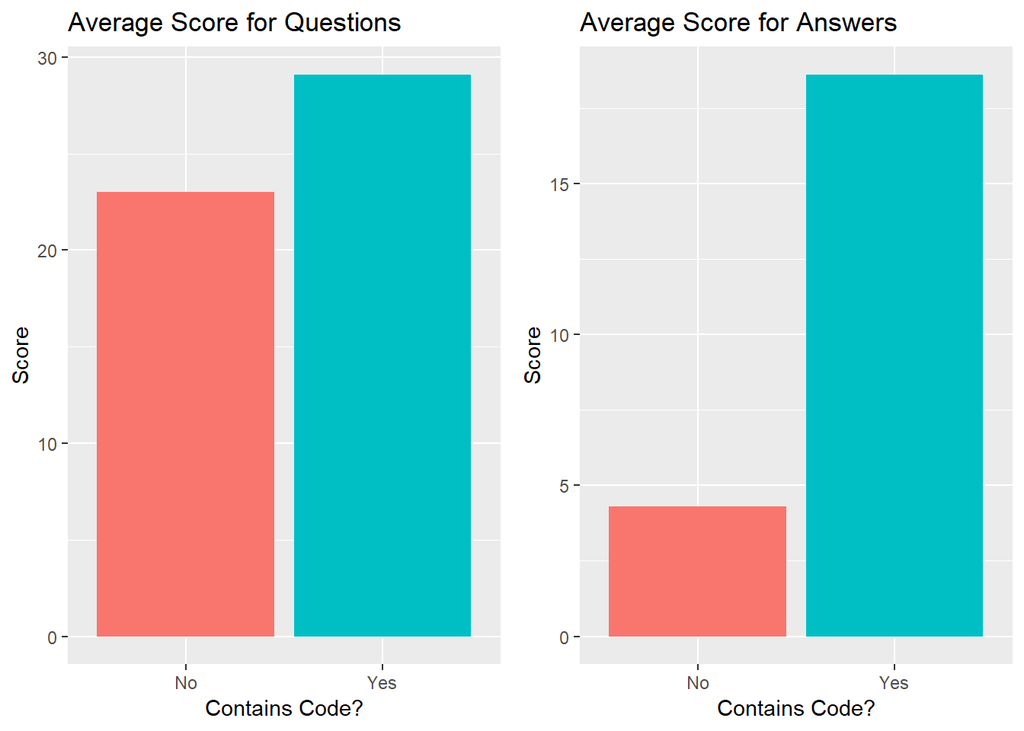

```r
mattq <- questions %>% mutate(ContainsCode = str_detect(Body, pattern="<code>"))
matta <- answers %>% mutate(ContainsCode = str_detect(Body, pattern="<code>"))

questionMeans <- tribble(
  ~Code, ~Mean,
  "Yes", colMeans( mattq[mattq$ContainsCode, "Score"], na.rm = TRUE),
  "No", colMeans( mattq[!mattq$ContainsCode, "Score"], na.rm = TRUE)
)
answerMeans <- tribble(
  ~Code, ~Mean,
  "Yes", colMeans( matta[matta$ContainsCode, "Score"], na.rm = TRUE),
  "No", colMeans( matta[!matta$ContainsCode, "Score"], na.rm = TRUE)
)

 q <- ggplot(data=questionMeans) +
  geom_bar(aes(x=Code, weight=Mean, fill=Code)) +
  labs(title="Average Score for Questions", x="Contains Code?", y="Score") +
   guides(fill=FALSE)
a <- ggplot(data=answerMeans) +
  geom_bar(aes(x=Code, weight=Mean, fill=Code)) +
  labs(title="Average Score for Answers", x="Contains Code?", y="Score") +  guides(fill=FALSE)

grid.arrange(q, a, ncol=2)
```

Questions and answers that contain code both have higher scores than questions and answers that do not contain code. The difference is much larger in answers. Questions with code in them receive 6 more points on average than questions without code. Answers with code receive 14 more points on average than answers without code. So, if you want to have a question or an answer with a high score, include some code. This is expected because questions about problems with code should include the code in the question. Similarly, answers about code problems should include the fixed code. Formatting code in the proper “code” section of a stack overflow post makes it very easy for future readers to find and read the code.

### Brandon

Does opening the question with a question word such as how increase feed back.

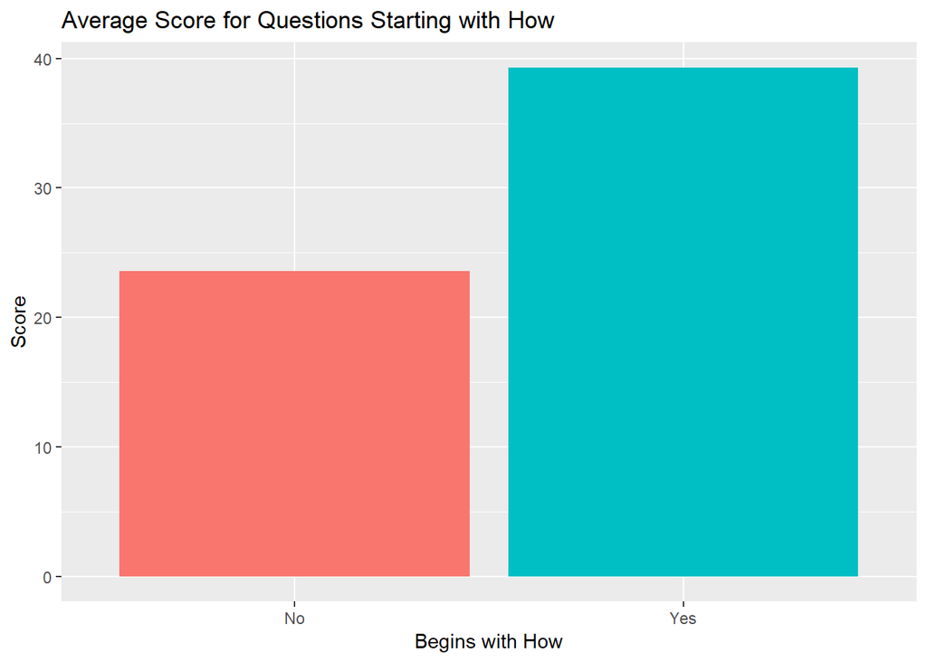

```r
brandonq <- questions %>% mutate(How = str_detect(Title, pattern="^How"))
brandonMeans <- tribble(~How, ~Mean, "Yes", colMeans( brandonq[brandonq$How, "Score"], na.rm = TRUE),
"No", colMeans( brandonq[!brandonq$How, "Score"], na.rm = TRUE)
)


ggplot(data=brandonMeans) +
  geom_bar(aes(x=How, weight=Mean, fill=How)) +
  labs(title="Average Score for Questions Starting with How", x="Begins with How", y="Score") +
   guides(fill=FALSE)
```

From the above graph it can be seen that that questions that begin with How on average have about 15 more points then questions that don’t begin with How. This can be because How grabs a persons attention when looking for questions to answer. Also when people look up similar problems most people will begin their question with “How” when they don’t know how to do something.

### Nick

```r
Answers <- read_csv("data/Answers_trunc.csv")
Answers <- select(Answers, -X7)
Questions <- read_csv("data/Questions_trunc.csv")
Questions <- select(Questions, -X7)

Qs <- select(Questions, Id, CreationDate)
colnames(Qs)[2] <- "QuestionDate"
Ans <- inner_join(Answers, Qs, by = c("ParentId" = "Id"))
Ans <- Ans %>% mutate(responseTime =  difftime(CreationDate,QuestionDate, units = "hours") )
Ans <- Ans %>% mutate(order = 0)
```

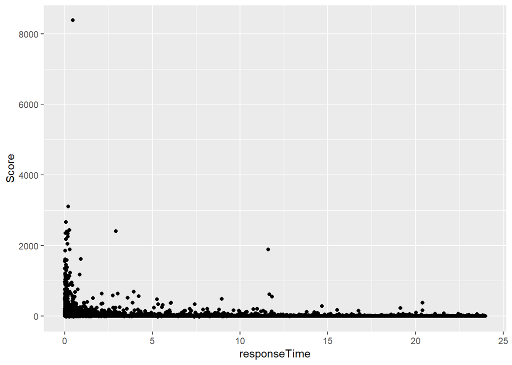

```r
ggplot(filter(Ans, responseTime > 0 & responseTime < 24))+
  geom_point(mapping = aes(responseTime,Score))
```

In this graph we can certainly see that the answeres with a very quick response time also are much more likely to recieve a greater score.

```r
users <- summarise(group_by(select(Ans, OwnerUserId, Score ), OwnerUserId), total = sum(Score))
users <- na.omit(users)

top_users <- head(arrange(users,desc(total)))

show(top_users)
```

```
## # A tibble: 6 x 2
##   OwnerUserId total
##         <dbl> <dbl>
## 1        9951 14341
## 2       95810 12768
## 3       10661  9973
## 4       16417  8962
## 5       17160  7323
## 6        1199  6763
```

Here is a chart that shows the top 6 users and their total combined score. This chart shows that some of the highest scored answers were posted by the same uses.

### Bing

My features are is how is the score affected when the word API is in the question?

```r
  APIquestions <- questions %>% filter(grepl("API",Title))
  APIanswers <- answers %>% filter(grepl("API",Body))

  #APIquestions
  #APIanswers

  t1 <- APIquestions %>% summarise(type = "questions about API", mean = mean(Score))
  t2 <- APIanswers %>% summarise(type = "answers about API", mean = mean(Score))
  t3 <- questions %>% summarise(type = "all questions", mean = mean(Score))
  t4 <- answers %>% summarise(type = "all answers", mean = mean(Score))

  t5 <- bind_rows(t1,t2, t3, t4)

  t5
```

| type | mean |
| --- | --- |
| questions about API | 8.035714 |
| answers about API | 8.170324 |
| all questions | 26.671418 |
| all answers | 12.960153 |

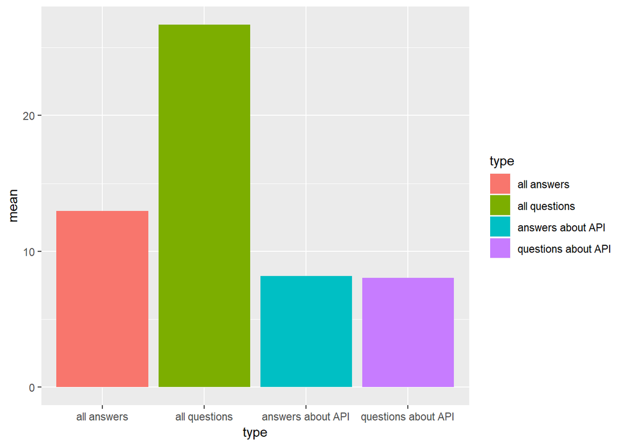

```r
  ggplot(data = t5) + geom_col(mapping = aes(x = type, y = mean, fill = type))
```

As we can see from our table that questions and answers about API are less than questions and answers in general. In my experience answers on forums about APIs have been hard to understand and implement, so it would make sense that the score is less for them. This can also be attributed to the fact that most people are not looking up and asking questions about APIs, with less exposure it would make it hard for the score for questions and answers about APIs to be more than the general population.